# R Notebook

# Poisonovo rozdělení

Příklad: Jestliže průměrná intenzita provozu na komunikaci je 12 vozidel za minutu, spočítejte pravděpodobnost, že za minutu projede právě 17 automobilů.

```r
dpois(17, lambda=12)
```

```
[1] 0.03832471
```

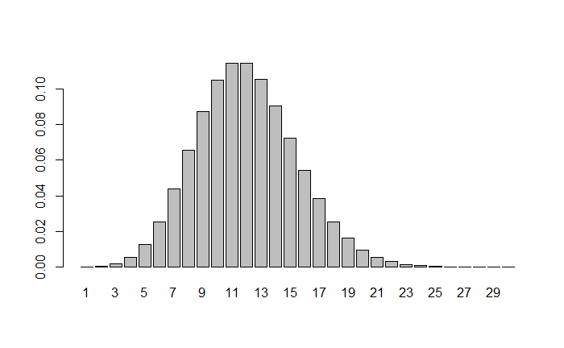

```r
d = dpois(1:30, lambda=12)
barplot(d, names.arg = 1:30)
```

Spočítejte pravděpodobnost, že za minutu projede 17 a více automobilů.

```r
ppois(16, lambda=12, lower=FALSE)
```

```
[1] 0.101291
```

Spočítáme pravděpodobnost pro hodnoty 1 až 30 a zobrazíme v grafu:

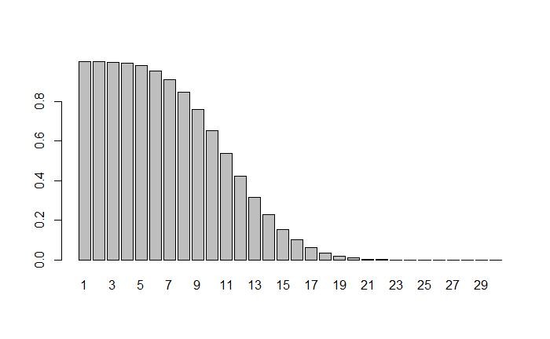

```r
p = ppois(1:30, lambda=12, lower.tail=FALSE)
barplot(p, names.arg = 1:30)
```

# Geometrické rozdělení

Geometrické rozdělení predikuje počet neúspěšných pokusů před prvním úspěšným pokusem v řadě jednotlivých nezávislých Bernouliho pokusů. V územním plánování lze toto využít pro predikci čekání na opravu nebo predikci selhání infrastruktury.

Příklad:

Jaká je pravděpodobnost, že při házení korunou hodíme pannu až v pátém hodu?

```r
dgeom(4, prob=0.5)
```

[output not shown]

Jaká je pravděpodobnost, že při házení korunou hodíme pannu až v n-tém hodu?

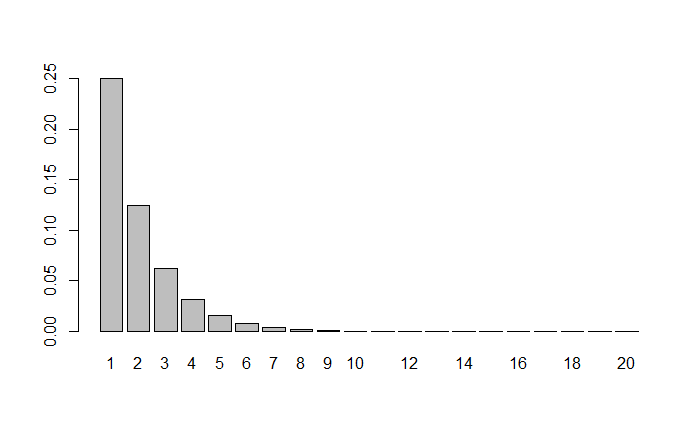

```r
d = dgeom(1:20, prob=0.5)
barplot(d, names.arg = 1:20)
```

Příklad: pravděpodobnost nehody na křižovatce

```r
p <- 1/10

dgeom(4, p)
```

```
[1] 0.06561
```

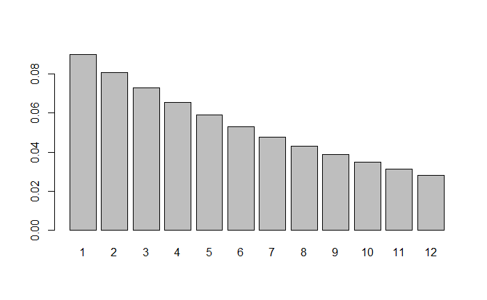

```r
d = dgeom(1:12, prob=p)
barplot(d, names.arg = 1:12)
```

Průměrný počet měsíců, do první dopravní nehody je (1-p)/p = 0.9/0.1=9 měsíců

# Exponenciální rozdělení

Příklad: doba mezi poruchami městského vodovodního systému.

Průměrný počet vážných poruch ve vodovodní síti města je jedna za 4 měsíce. Chceme odhadnout pravděpodobnost, že další porucha nastane přesně za 1 měsíc.

```r
lambda = 1/4
dexp(1, rate=lambda)
```

```
[1] 0.1947002
```

```r
lambda*exp(-lambda * 1)
```

```
[1] 0.1947002
```

Jaká je pravděpodobnost výskytu další poruchy přesně v prvním, druhém, třetím měsíci atd…

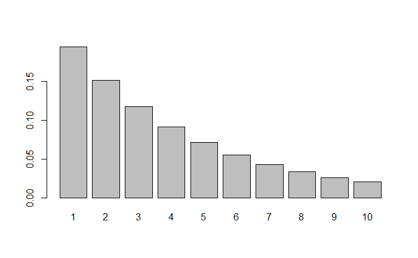

```r
doba = dexp(1:10, rate=lambda)
barplot(doba, names.arg = 1:10)
```

```r
pexp(6, rate=lambda)
```

```
[1] 0.7768698
```

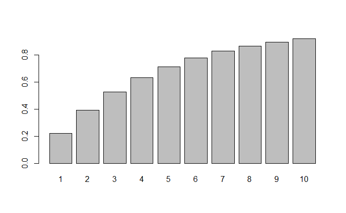

```r
doba = pexp(1:10, rate=lambda)
barplot(doba, names.arg = 1:10)
```

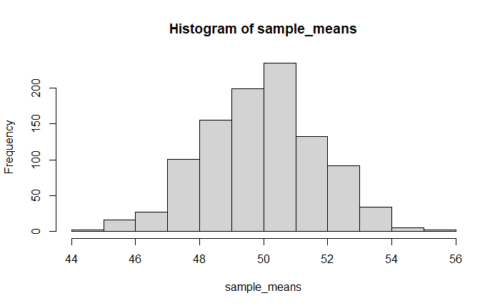

```r
set.seed(123)  # For reproducibility
n <- 30  # Sample size per mean
mu <- 50  # Mean of the normal distribution
sigma <- 10  # Standard deviation

sample_means <- replicate(1000, mean(rnorm(n, mean = mu, sd = sigma)))
hist(sample_means)
```